# AnEx Phase I

Kelsey Jesser

6/16/2025

#Clear environment

```r
rm(list = ls())
```

#Load libraries

```r
library(ggplot2)
library(dplyr)
library(kableExtra)
library(stringr)
library(tibble)
library(reshape2)
library(ggpubr)
library(rstatix)
library(RVAideMemoire)
library(tidyr)
library(purrr)
library(sandwich)
library(lmtest)
library(tidyr)
library(gt)
library(gtsummary)
library(forcats)
library(purrr)
library(flextable)
library(geepack)
```

#Import and reformat data

```r
#metadata
HH<-read.csv("AnExII_ODKdata_qPCRMST_KJ.csv")%>%
  select(c(9, 82, 85, 105:106, 126, 128, 180, 184, 186, 207, 209:210, 212, 232, 234, 238, 255:260, 293:295, 297, 315:318))%>%
  mutate(Household=factor(Household))

#abundance data
data<-read.csv("Updated_AnExII.csv")%>%
  dplyr::mutate_at(vars(6:11), as.numeric)%>%
  dplyr::mutate(GenBac_log=log10(GenBac))%>%
  dplyr::mutate(GenBac_log=str_replace(GenBac_log, "BDL", "1250"))%>%
  dplyr::mutate(GenBac_log=str_replace(GenBac_log, "DNQ", "2500"))%>%
  dplyr::mutate(across(starts_with("GenBac"), as.numeric))%>%
  dplyr::mutate(Household=factor(Household))%>%
  dplyr::mutate(Site=factor(Site))%>%
  dplyr::mutate(Sample_Type=factor(Sample_Type))%>%
  dplyr::mutate(Sample_Type = if_else(Sample_Type == "Mom's hands", "Adult hands", Sample_Type))%>%
  dplyr::mutate(Sample_Type = if_else(Sample_Type == "Child's hands", "Child hands", Sample_Type))%>%
  left_join(HH, by = "Household")

#marker presence absence
prev<-read.csv("Updated_AnExII GenBac raw.csv")%>%
  dplyr::mutate(across(6:11, ~str_replace(., "BDL", "0")))%>%
  dplyr::mutate(across(6:11, ~str_replace(., "DNQ", "1")))%>%
  mutate_at(vars(6:11), as.numeric)%>%
  mutate(Site=as.factor(Site))%>%
  mutate(Sample_Type=as.factor(Sample_Type))%>%
  mutate(Household=as.factor(Household))%>%
  rowwise()%>%
  dplyr::mutate(Any_animal_marker=sum(dplyr::c_across(8:11)))%>%
  dplyr::mutate(Any_host_marker=sum(dplyr::c_across(7:11)))%>%
  dplyr::mutate(Any_marker=sum(dplyr::c_across(6:11)))%>%
  dplyr::mutate(across(6:14, ~if_else(. >0, 1, .)))%>%
  mutate(Sample_Type = if_else(Sample_Type == "Mom's hands", "Adult hands", Sample_Type))%>%
  mutate(Sample_Type = if_else(Sample_Type == "Child's hands", "Child hands", Sample_Type))%>%
  left_join(HH, by = "Household")

samples<-table(data$Sample_Type)%>%
  as.data.frame()%>%
  dplyr::rename(Sample_Type=Var1)
```

#MST marker prevalence in any sample

```r
prev <- prev %>%
  mutate(any_host = as.integer(HF183 == 1 | Rum2Bac == 1 | Pig2Bac == 1 | DG37 == 1 | GFD == 1),
         any_animal = as.integer(Rum2Bac == 1 | Pig2Bac == 1 | DG37 == 1 | GFD == 1))

perc_all <- data.frame(
  GenBac = sum(prev$GenBac) / 586 * 100,
  HF183 = sum(prev$HF183) / 586 * 100,
  DG37 = sum(prev$DG37) / 586 * 100,
  GFD = sum(prev$GFD) / 586 * 100,
  Pig2Bac = sum(prev$Pig2Bac) / 586 * 100,
  Rum2Bac = sum(prev$Rum2Bac) / 586 * 100,
  Any_Host = sum(prev$any_host) / 586 * 100,
  Any_Animal = sum(prev$any_animal) / 586 * 100
) %>%
  mutate(across(where(is.numeric), round, 2))

kbl(perc_all) %>%
  kable_styling(latex_options = "scale_down", font_size = 14) %>%
  kable_styling(bootstrap_options = "hover", full_width = FALSE) %>%
  add_header_above(c("MST marker % prevalence in any sample" = 8))
```

| MST marker % prevalence in any sample GenBac | MST marker % prevalence in any sample HF183 | MST marker % prevalence in any sample DG37 | MST marker % prevalence in any sample GFD | MST marker % prevalence in any sample Pig2Bac | MST marker % prevalence in any sample Rum2Bac | MST marker % prevalence in any sample Any_Host | MST marker % prevalence in any sample Any_Animal |
| --- | --- | --- | --- | --- | --- | --- | --- |
| 77.82 | 15.36 | 3.58 | 4.1 | 2.05 | 0.51 | 19.97 | 8.36 |

```r
total_pos <- data.frame(
  GenBac = sum(prev$GenBac),
  HF183 = sum(prev$HF183),
  DG37 = sum(prev$DG37),
  GFD = sum(prev$GFD),
  Pig2Bac = sum(prev$Pig2Bac),
  Rum2Bac = sum(prev$Rum2Bac),
  Any_Host = sum(prev$any_host),
  Any_Animal = sum(prev$any_animal)
)

kbl(total_pos) %>%
  kable_styling(latex_options = "scale_down", font_size = 14) %>%
  kable_styling(bootstrap_options = "hover", full_width = FALSE) %>%
  add_header_above(c("MST marker detections in any sample" = 8))
```

| MST marker detections in any sample GenBac | MST marker detections in any sample HF183 | MST marker detections in any sample DG37 | MST marker detections in any sample GFD | MST marker detections in any sample Pig2Bac | MST marker detections in any sample Rum2Bac | MST marker detections in any sample Any_Host | MST marker detections in any sample Any_Animal |
| --- | --- | --- | --- | --- | --- | --- | --- |
| 456 | 90 | 21 | 24 | 12 | 3 | 117 | 49 |

#MST marker prevalence by sample type

```r
prev_melt<-prev %>%
  melt(id.vars=c("Code", "Sample_Type", "Site", "Household"), variable.name=("measurement"), value.name="value")

detections<-prev%>%
  select(c(3, 6:14))%>%
  melt(id.vars=c("Sample_Type"), variable.name=("MST marker"), value.name="value")%>%
  group_by(Sample_Type, `MST marker`)%>%
  dplyr::summarize(`Positive sample n`=sum(value), `Total sample n`=n(), Percent= (sum(value)/n()*100))%>%
  mutate(across(where(is.numeric), ~ round(., 2)))

kbl(detections)%>%
  kable_styling(latex_options="scale_down", font_size=14)%>%
  kable_styling(bootstrap_options="hover", full_width=F)%>%
  add_header_above(c("MST marker prevalence by sample type"=5))
```

| MST marker prevalence by sample type Sample_Type | MST marker prevalence by sample type MST marker | MST marker prevalence by sample type Positive sample n | MST marker prevalence by sample type Total sample n | MST marker prevalence by sample type Percent |
| --- | --- | --- | --- | --- |
| Adult hands | GenBac | 59 | 59 | 100.00 |
| Adult hands | HF183 | 31 | 59 | 52.54 |
| Adult hands | Rum2Bac | 1 | 59 | 1.69 |
| Adult hands | Pig2Bac | 4 | 59 | 6.78 |
| Adult hands | DG37 | 4 | 59 | 6.78 |
| Adult hands | GFD | 3 | 59 | 5.08 |
| Adult hands | Any_animal_marker | 10 | 59 | 16.95 |
| Adult hands | Any_host_marker | 35 | 59 | 59.32 |
| Adult hands | Any_marker | 59 | 59 | 100.00 |
| Cellphone | GenBac | 29 | 30 | 96.67 |
| Cellphone | HF183 | 1 | 30 | 3.33 |
| Cellphone | Rum2Bac | 0 | 30 | 0.00 |
| Cellphone | Pig2Bac | 0 | 30 | 0.00 |
| Cellphone | DG37 | 1 | 30 | 3.33 |
| Cellphone | GFD | 0 | 30 | 0.00 |
| Cellphone | Any_animal_marker | 1 | 30 | 3.33 |
| Cellphone | Any_host_marker | 2 | 30 | 6.67 |
| Cellphone | Any_marker | 29 | 30 | 96.67 |
| Child hands | GenBac | 31 | 31 | 100.00 |
| Child hands | HF183 | 15 | 31 | 48.39 |
| Child hands | Rum2Bac | 0 | 31 | 0.00 |
| Child hands | Pig2Bac | 0 | 31 | 0.00 |
| Child hands | DG37 | 5 | 31 | 16.13 |
| Child hands | GFD | 2 | 31 | 6.45 |
| Child hands | Any_animal_marker | 7 | 31 | 22.58 |
| Child hands | Any_host_marker | 17 | 31 | 54.84 |
| Child hands | Any_marker | 31 | 31 | 100.00 |
| Dish drying surface | GenBac | 9 | 10 | 90.00 |
| Dish drying surface | HF183 | 0 | 10 | 0.00 |
| Dish drying surface | Rum2Bac | 0 | 10 | 0.00 |

[output cut: 96 more lines]

#Prevalence plot

```r
#format data
counts<-prev %>%
  select(-matches("Number"))%>%
  select(c(3, 6:11))%>% #can update this line to include additional data (ex: any host, any animal marker)
  melt(id.vars= c("Sample_Type"))%>%
  group_by(Sample_Type, variable)%>%
  dplyr::summarize(cnt=n())
sums<- prev %>%
  select(-matches("Number"))%>%
  select(c(3, 6:11))%>% #can update this line to include additional data (ex: any host, any animal marker)
  melt(id.vars= c("Sample_Type"))%>%
  group_by(Sample_Type, variable)%>%
  dplyr::summarise(across(value, sum))
```

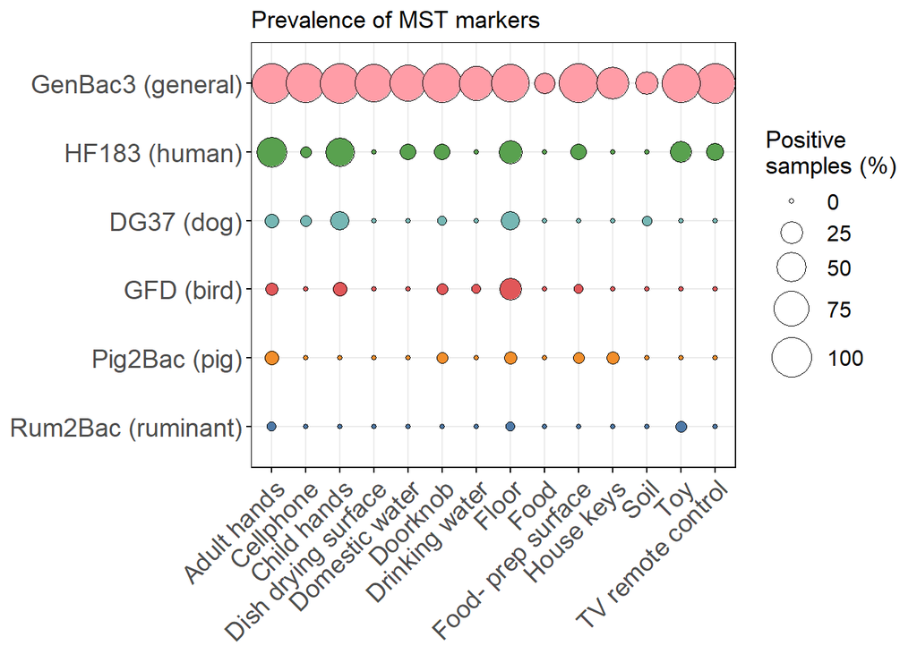

```r
prev_sampletype<-data.frame(Sample_Type=counts$Sample_Type,
                            Assay=counts$variable,
                            Total_Samples=counts$cnt,
                            Total_Pos=sums$value,
                            Percent_Pos=sums$value/counts$cnt*100)

prev_sampletype_balloon<-prev_sampletype %>%
  subset(Assay != "Human_positive" & Assay != "Any_positive" & Assay != "Any_animal_pos" & Assay != "Any_source_spec_pos")

#plot
prev_sampletype_balloon$Assay <- factor(prev_sampletype_balloon$Assay, levels = c("Rum2Bac", "Pig2Bac", "GFD", "DG37", "HF183", "GenBac"))

labels<-c("Rum2Bac (ruminant)", "Pig2Bac (pig)", "GFD (bird)", "DG37 (dog)", "HF183 (human)", "GenBac3 (general)")


cols <- c("GenBac"="#FF9DA7", "HF183"="#59A14F", "DG37"="#76B7B4", "GFD"="#E15759", "Pig2Bac"="#F28E2B", "Rum2Bac"="#4E79A7")

prevalence_plot<-ggballoonplot(prev_sampletype_balloon,
             x="Sample_Type",
             y="Assay",
             fill="Assay",
             size="Percent_Pos",
             ggtheme=theme_minimal())+
  scale_fill_manual(values=cols, labels=scales::percent)+
  scale_y_discrete(labels=labels)+
  #scale_x_discrete(labels=labels2)+
  ggtitle("Prevalence of MST markers")+
  guides(fill = "none",
         size=guide_legend(title="Positive\nsamples (%)"))+
  theme(axis.text.y=element_text(size=14),
        axis.text.x=element_text(size=14),
        legend.background=element_rect(color=NA),
        legend.text=element_text(size=12),
        legend.title=element_text(size=13),
        panel.border=element_rect(color="black", fill=NA))

prevalence_plot
```

#Sample type and MST marker detection

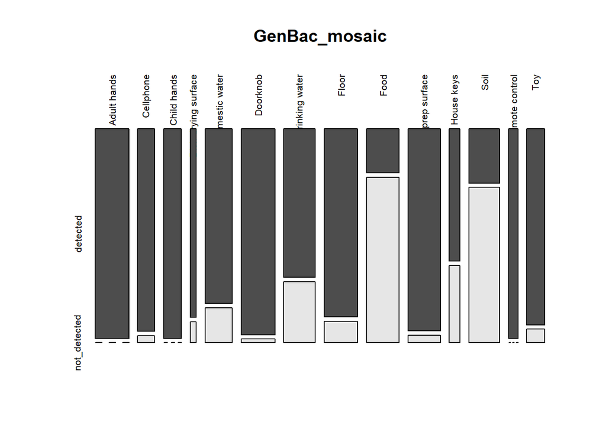

```r
markers<-c("GenBac", "HF183", "DG37", "Pig2Bac", "Pig2Bac", "Rum2Bac")

#GenBac
GenBac_counts<-prev%>%
  group_by(Sample_Type)%>%
  dplyr::summarize(detected=sum(GenBac))%>%
  left_join(samples, by= "Sample_Type")%>%
  mutate(not_detected=Freq-detected)%>%
  select(-c(Freq))

GenBac_mosaic<-GenBac_counts%>%
  column_to_rownames("Sample_Type")%>%
  as.matrix()
mosaicplot(GenBac_mosaic, color=TRUE, las=3)
```

```r
fisher_GenBac<-GenBac_counts%>%
  column_to_rownames("Sample_Type")%>%
  fisher_test(simulate.p.value = TRUE, B= 1e4)
fisher_GenBac #p<0.0001, run pairwise posthoc tests
```

```
## # A tibble: 1 × 3
##       n      p p.signif
## * <dbl>  <dbl> <chr>
## 1   585 0.0001 ****
```

```r
fisher_GenBac_multi_corrected<-GenBac_counts%>%
  column_to_rownames("Sample_Type")%>%
  as.matrix()%>%
  fisher.multcomp(p.method = "BH")
fisher_GenBac_multi_corrected$p.value%>%
  as.data.frame()%>%
  mutate(across(where(is.numeric), ~ round(., 3)))%>%
  kbl()%>%
  kable_styling(bootstrap_options="hover", full_width=F)%>%
  add_header_above(c("GenBac pairwise Fisher's test adj p-values"=14))
```

| GenBac pairwise Fisher’s test adj p-values | GenBac pairwise Fisher’s test adj p-values Adult hands | GenBac pairwise Fisher’s test adj p-values Cellphone | GenBac pairwise Fisher’s test adj p-values Child hands | GenBac pairwise Fisher’s test adj p-values Dish drying surface | GenBac pairwise Fisher’s test adj p-values Domestic water | GenBac pairwise Fisher’s test adj p-values Doorknob | GenBac pairwise Fisher’s test adj p-values Drinking water | GenBac pairwise Fisher’s test adj p-values Floor | GenBac pairwise Fisher’s test adj p-values Food | GenBac pairwise Fisher’s test adj p-values Food- prep surface | GenBac pairwise Fisher’s test adj p-values House keys | GenBac pairwise Fisher’s test adj p-values Soil | GenBac pairwise Fisher’s test adj p-values TV remote control |
| --- | --- | --- | --- | --- | --- | --- | --- | --- | --- | --- | --- | --- | --- |
| Cellphone | 0.487 | NA | NA | NA | NA | NA | NA | NA | NA | NA | NA | NA | NA |
| Child hands | 1.000 | 0.639 | NA | NA | NA | NA | NA | NA | NA | NA | NA | NA | NA |
| Dish drying surface | 0.259 | 0.592 | 0.396 | NA | NA | NA | NA | NA | NA | NA | NA | NA | NA |
| Domestic water | 0.003 | 0.258 | 0.041 | 1.000 | NA | NA | NA | NA | NA | NA | NA | NA | NA |
| Doorknob | 1.000 | 1.000 | 1.000 | 0.413 | 0.025 | NA | NA | NA | NA | NA | NA | NA | NA |
| Drinking water | 0.000 | 0.011 | 0.001 | 0.413 | 0.289 | 0.000 | NA | NA | NA | NA | NA | NA | NA |
| Floor | 0.057 | 0.565 | 0.177 | 1.000 | 0.542 | 0.216 | 0.036 | NA | NA | NA | NA | NA | NA |
| Food | 0.000 | 0.000 | 0.000 | 0.000 | 0.000 | 0.000 | 0.000 | 0.000 | NA | NA | NA | NA | NA |
| Food- prep surface | 0.396 | 1.000 | 0.684 | 0.542 | 0.083 | 0.746 | 0.001 | 0.413 | 0.000 | NA | NA | NA | NA |
| House keys | 0.000 | 0.010 | 0.002 | 0.338 | 0.202 | 0.000 | 0.714 | 0.029 | 0.004 | 0.002 | NA | NA | NA |
| Soil | 0.000 | 0.000 | 0.000 | 0.001 | 0.000 | 0.000 | 0.000 | 0.000 | 0.784 | 0.000 | 0.014 | NA | NA |
| TV remote control | 1.000 | 1.000 | 1.000 | 0.542 | 0.317 | 1.000 | 0.034 | 0.486 | 0.000 | 1.000 | 0.023 | 0 | NA |
| Toy | 0.216 | 1.000 | 0.639 | 1.000 | 0.448 | 0.413 | 0.032 | 0.839 | 0.000 | 0.746 | 0.040 | 0 | 0.684 |

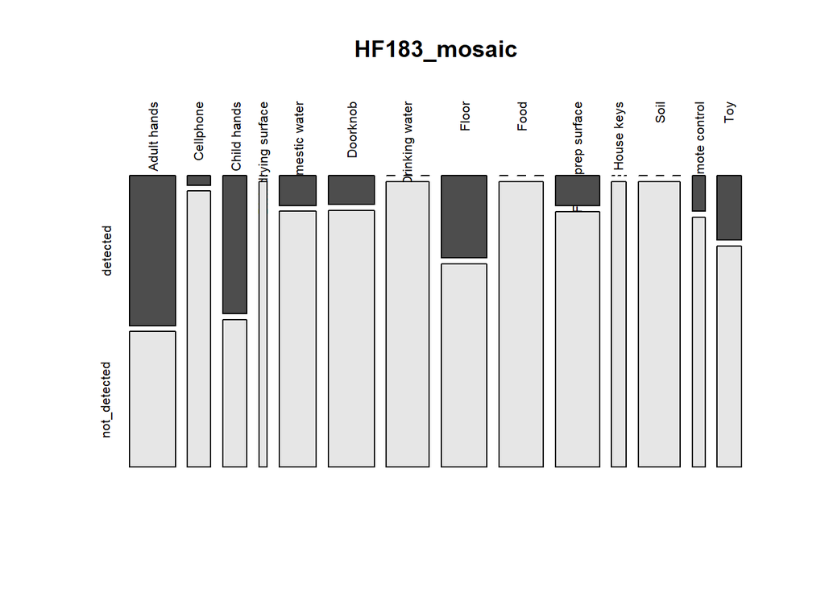

```r
#write.csv(fisher_GenBac_multi_corrected$p.value, file="GenBac_fisher_pvalues.csv")

fisher_GenBac3_posthoc <- fisher_GenBac_multi_corrected$p.value %>%
  as.data.frame() %>%
  mutate(across(where(is.numeric), ~ case_when(
    is.na(.)    ~ "",
    . < 0.001   ~ "<0.001",
    TRUE        ~ formatC(., format = "f", digits = 3)
  )))
#write.csv(fisher_GenBac3_posthoc, file = "fisher_GenBac3_posthoc.csv")

#HF183
HF183_counts<-prev%>%
  dplyr::group_by(Sample_Type)%>%
  dplyr::summarize(detected=sum(HF183))%>%
  dplyr::left_join(samples, by= "Sample_Type")%>%
  mutate(not_detected=Freq-detected)%>%
  select(-c(Freq))

HF183_mosaic<-HF183_counts%>%
  column_to_rownames("Sample_Type")%>%
  as.matrix()
mosaicplot(HF183_mosaic, color=TRUE, las=3)
```

```r
fisher_HF183<-HF183_counts%>%
  column_to_rownames("Sample_Type")%>%
  fisher_test(simulate.p.value = TRUE, B= 1e4)
fisher_HF183 #p<0.0001, run pairwise posthoc tests
```

```
## # A tibble: 1 × 3
##       n      p p.signif
## * <dbl>  <dbl> <chr>
## 1   585 0.0001 ****
```

```r
fisher_HF183_multi_corrected<-HF183_counts%>%
  column_to_rownames("Sample_Type")%>%
  as.matrix()%>%
  fisher.multcomp(p.method = "BH")
fisher_HF183_multi_corrected$p.value%>%
  as.data.frame()%>%
  mutate(across(where(is.numeric), ~ round(., 3)))%>%
  kbl()%>%
  kable_styling(bootstrap_options="hover", full_width=F)%>%
  add_header_above(c("HF183 pairwise Fisher's test adj p-values"=14))
```

| HF183 pairwise Fisher’s test adj p-values | HF183 pairwise Fisher’s test adj p-values Adult hands | HF183 pairwise Fisher’s test adj p-values Cellphone | HF183 pairwise Fisher’s test adj p-values Child hands | HF183 pairwise Fisher’s test adj p-values Dish drying surface | HF183 pairwise Fisher’s test adj p-values Domestic water | HF183 pairwise Fisher’s test adj p-values Doorknob | HF183 pairwise Fisher’s test adj p-values Drinking water | HF183 pairwise Fisher’s test adj p-values Floor | HF183 pairwise Fisher’s test adj p-values Food | HF183 pairwise Fisher’s test adj p-values Food- prep surface | HF183 pairwise Fisher’s test adj p-values House keys | HF183 pairwise Fisher’s test adj p-values Soil | HF183 pairwise Fisher’s test adj p-values TV remote control |
| --- | --- | --- | --- | --- | --- | --- | --- | --- | --- | --- | --- | --- | --- |
| Cellphone | 0.000 | NA | NA | NA | NA | NA | NA | NA | NA | NA | NA | NA | NA |
| Child hands | 1.000 | 0.000 | NA | NA | NA | NA | NA | NA | NA | NA | NA | NA | NA |
| Dish drying surface | 0.006 | 1.000 | 0.024 | NA | NA | NA | NA | NA | NA | NA | NA | NA | NA |
| Domestic water | 0.000 | 0.565 | 0.002 | 0.757 | NA | NA | NA | NA | NA | NA | NA | NA | NA |
| Doorknob | 0.000 | 0.573 | 0.001 | 0.757 | 1.000 | NA | NA | NA | NA | NA | NA | NA | NA |
| Drinking water | 0.000 | 0.516 | 0.000 | 1.000 | 0.054 | 0.062 | NA | NA | NA | NA | NA | NA | NA |
| Floor | 0.045 | 0.016 | 0.189 | 0.109 | 0.063 | 0.054 | 0.000 | NA | NA | NA | NA | NA | NA |
| Food | 0.000 | 0.514 | 0.000 | 1.000 | 0.054 | 0.062 | 1.000 | 0.000 | NA | NA | NA | NA | NA |
| Food- prep surface | 0.000 | 0.573 | 0.001 | 0.757 | 1.000 | 1.000 | 0.062 | 0.054 | 0.062 | NA | NA | NA | NA |
| House keys | 0.000 | 1.000 | 0.001 | 1.000 | 0.496 | 0.501 | 1.000 | 0.027 | 1.000 | 0.501 | NA | NA | NA |
| Soil | 0.000 | 0.516 | 0.000 | 1.000 | 0.055 | 0.062 | 1.000 | 0.000 | 1.000 | 0.062 | 1.000 | NA | NA |
| TV remote control | 0.016 | 0.445 | 0.062 | 0.690 | 1.000 | 0.855 | 0.098 | 0.501 | 0.094 | 1.000 | 0.340 | 0.098 | NA |
| Toy | 0.025 | 0.102 | 0.115 | 0.288 | 0.340 | 0.225 | 0.002 | 0.795 | 0.002 | 0.342 | 0.075 | 0.002 | 0.869 |

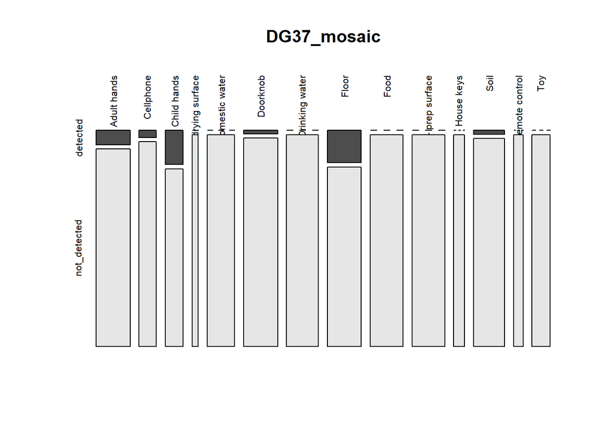

```r
#write.csv(fisher_HF183_multi_corrected$p.value, file="HF183_fisher_pvalues.csv")

fisher_HF183_posthoc <- fisher_HF183_multi_corrected$p.value %>%
  as.data.frame() %>%
  mutate(across(where(is.numeric), ~ case_when(
    is.na(.)    ~ "",
    . < 0.001   ~ "<0.001",
    TRUE        ~ formatC(., format = "f", digits = 3)
  )))
write.csv(fisher_HF183_posthoc, file = "fisher_HF183_posthoc.csv")

#DG37
DG37_counts<-prev%>%
  dplyr::group_by(Sample_Type)%>%
  dplyr::summarize(detected=sum(DG37))%>%
  dplyr::left_join(samples, by= "Sample_Type")%>%
  mutate(not_detected=Freq-detected)%>%
  select(-c(Freq))

DG37_mosaic<-DG37_counts%>%
  column_to_rownames("Sample_Type")%>%
  as.matrix()
mosaicplot(DG37_mosaic, color=TRUE, las=3)
```

```r
fisher_DG37<-DG37_counts%>%
  column_to_rownames("Sample_Type")%>%
  fisher_test(simulate.p.value = TRUE, B= 1e4)
fisher_DG37 #p<0.0001, run pairwise posthoc tests
```

```
## # A tibble: 1 × 3
##       n      p p.signif
## * <dbl>  <dbl> <chr>
## 1   585 0.0001 ****
```

```r
fisher_DG37_multi_corrected<-DG37_counts%>%
  column_to_rownames("Sample_Type")%>%
  as.matrix()%>%
  fisher.multcomp(p.method = "BH")
fisher_DG37_multi_corrected$p.value%>%
  as.data.frame()%>%
  mutate(across(where(is.numeric), ~ round(., 3)))%>%
  kbl()%>%
  kable_styling(bootstrap_options="hover", full_width=F)%>%
  add_header_above(c("DG37 pairwise Fisher's test adj p-values"=14))
```

| DG37 pairwise Fisher’s test adj p-values | DG37 pairwise Fisher’s test adj p-values Adult hands | DG37 pairwise Fisher’s test adj p-values Cellphone | DG37 pairwise Fisher’s test adj p-values Child hands | DG37 pairwise Fisher’s test adj p-values Dish drying surface | DG37 pairwise Fisher’s test adj p-values Domestic water | DG37 pairwise Fisher’s test adj p-values Doorknob | DG37 pairwise Fisher’s test adj p-values Drinking water | DG37 pairwise Fisher’s test adj p-values Floor | DG37 pairwise Fisher’s test adj p-values Food | DG37 pairwise Fisher’s test adj p-values Food- prep surface | DG37 pairwise Fisher’s test adj p-values House keys | DG37 pairwise Fisher’s test adj p-values Soil | DG37 pairwise Fisher’s test adj p-values TV remote control |
| --- | --- | --- | --- | --- | --- | --- | --- | --- | --- | --- | --- | --- | --- |
| Cellphone | 1.000 | NA | NA | NA | NA | NA | NA | NA | NA | NA | NA | NA | NA |
| Child hands | 0.929 | 0.741 | NA | NA | NA | NA | NA | NA | NA | NA | NA | NA | NA |
| Dish drying surface | 1.000 | 1.000 | 0.980 | NA | NA | NA | NA | NA | NA | NA | NA | NA | NA |
| Domestic water | 0.603 | 1.000 | 0.086 | 1.00 | NA | NA | NA | NA | NA | NA | NA | NA | NA |
| Doorknob | 0.980 | 1.000 | 0.144 | 1.00 | 1.000 | NA | NA | NA | NA | NA | NA | NA | NA |
| Drinking water | 0.603 | 0.980 | 0.063 | 1.00 | 1.000 | 1.000 | NA | NA | NA | NA | NA | NA | NA |
| Floor | 0.870 | 0.640 | 1.000 | 0.98 | 0.063 | 0.144 | 0.063 | NA | NA | NA | NA | NA | NA |
| Food | 0.603 | 0.980 | 0.063 | 1.00 | 1.000 | 1.000 | 1.000 | 0.063 | NA | NA | NA | NA | NA |
| Food- prep surface | 0.603 | 0.980 | 0.063 | 1.00 | 1.000 | 1.000 | 1.000 | 0.063 | 1 | NA | NA | NA | NA |
| House keys | 1.000 | 1.000 | 0.640 | 1.00 | 1.000 | 1.000 | 1.000 | 0.603 | 1 | 1 | NA | NA | NA |
| Soil | 0.980 | 1.000 | 0.172 | 1.00 | 1.000 | 1.000 | 1.000 | 0.144 | 1 | 1 | 1 | NA | NA |
| TV remote control | 1.000 | 1.000 | 0.640 | 1.00 | 1.000 | 1.000 | 1.000 | 0.741 | 1 | 1 | 1 | 1 | NA |
| Toy | 0.980 | 1.000 | 0.341 | 1.00 | 1.000 | 1.000 | 1.000 | 0.174 | 1 | 1 | 1 | 1 | 1 |

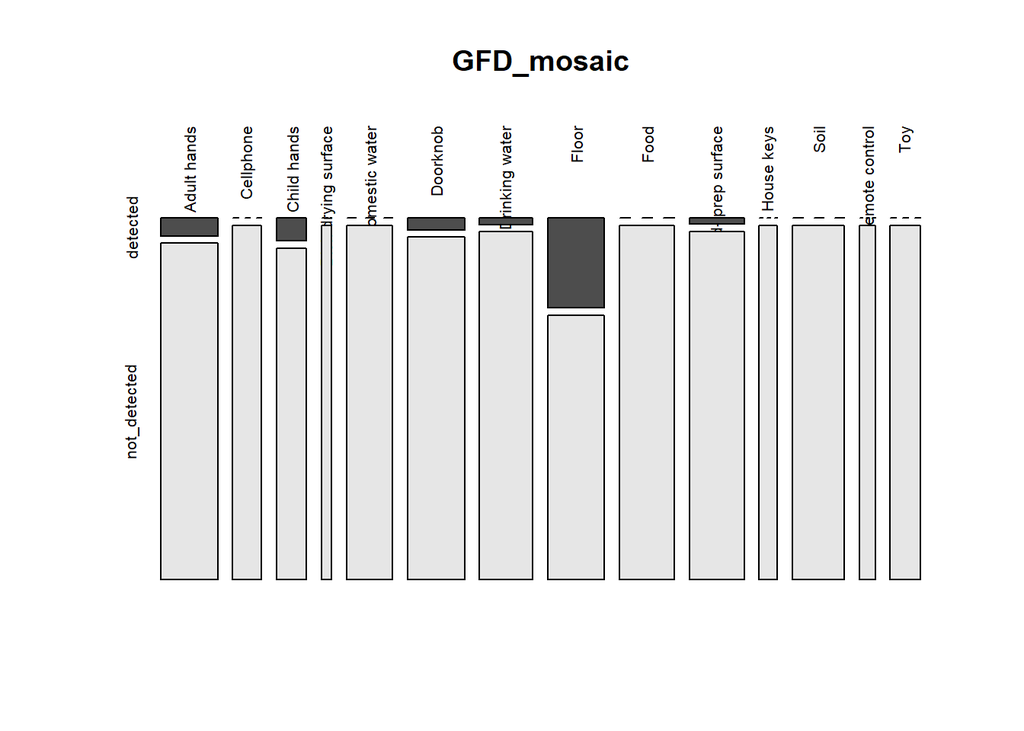

```r
#write.csv(fisher_HF183_multi_corrected$p.value, file="DG37_fisher_pvalues.csv")

fisher_DG37_posthoc <- fisher_DG37_multi_corrected$p.value %>%
  as.data.frame() %>%
  mutate(across(where(is.numeric), ~ case_when(
    is.na(.)    ~ "",
    . < 0.001   ~ "<0.001",
    TRUE        ~ formatC(., format = "f", digits = 3)
  )))
#write.csv(fisher_DG37_posthoc, file = "fisher_DG367_posthoc.csv")

#GFD
GFD_counts<-prev%>%
  dplyr::group_by(Sample_Type)%>%
  dplyr::summarize(detected=sum(GFD))%>%
  dplyr::left_join(samples, by= "Sample_Type")%>%
  mutate(not_detected=Freq-detected)%>%
  select(-c(Freq))

GFD_mosaic<-GFD_counts%>%
  column_to_rownames("Sample_Type")%>%
  as.matrix()
mosaicplot(GFD_mosaic, color=TRUE, las=3)
```

```r
fisher_GFD<-GFD_counts%>%
  column_to_rownames("Sample_Type")%>%
  fisher_test(simulate.p.value = TRUE, B= 1e4)
fisher_GFD #p<0.0001, run pairwise posthoc tests
```

```
## # A tibble: 1 × 3
##       n      p p.signif
## * <dbl>  <dbl> <chr>
## 1   585 0.0001 ****
```

```r
fisher_GFD_multi_corrected<-GFD_counts%>%
  column_to_rownames("Sample_Type")%>%
  as.matrix()%>%
  fisher.multcomp(p.method = "BH")
fisher_GFD_multi_corrected$p.value%>%
  as.data.frame()%>%
  mutate(across(where(is.numeric), ~ round(., 3)))%>%
  kbl()%>%
  kable_styling(bootstrap_options="hover", full_width=F)%>%
  add_header_above(c("GFD pairwise Fisher's test adj p-values"=14))
```

| GFD pairwise Fisher’s test adj p-values | GFD pairwise Fisher’s test adj p-values Adult hands | GFD pairwise Fisher’s test adj p-values Cellphone | GFD pairwise Fisher’s test adj p-values Child hands | GFD pairwise Fisher’s test adj p-values Dish drying surface | GFD pairwise Fisher’s test adj p-values Domestic water | GFD pairwise Fisher’s test adj p-values Doorknob | GFD pairwise Fisher’s test adj p-values Drinking water | GFD pairwise Fisher’s test adj p-values Floor | GFD pairwise Fisher’s test adj p-values Food | GFD pairwise Fisher’s test adj p-values Food- prep surface | GFD pairwise Fisher’s test adj p-values House keys | GFD pairwise Fisher’s test adj p-values Soil | GFD pairwise Fisher’s test adj p-values TV remote control |
| --- | --- | --- | --- | --- | --- | --- | --- | --- | --- | --- | --- | --- | --- |
| Cellphone | 1.000 | NA | NA | NA | NA | NA | NA | NA | NA | NA | NA | NA | NA |
| Child hands | 1.000 | 1.000 | NA | NA | NA | NA | NA | NA | NA | NA | NA | NA | NA |
| Dish drying surface | 1.000 | 1.000 | 1.000 | NA | NA | NA | NA | NA | NA | NA | NA | NA | NA |
| Domestic water | 1.000 | 1.000 | 0.858 | 1.000 | NA | NA | NA | NA | NA | NA | NA | NA | NA |
| Doorknob | 1.000 | 1.000 | 1.000 | 1.000 | 1.000 | NA | NA | NA | NA | NA | NA | NA | NA |
| Drinking water | 1.000 | 1.000 | 1.000 | 1.000 | 1.000 | 1.000 | NA | NA | NA | NA | NA | NA | NA |
| Floor | 0.039 | 0.021 | 0.341 | 0.724 | 0.003 | 0.016 | 0.004 | NA | NA | NA | NA | NA | NA |
| Food | 1.000 | 1.000 | 0.790 | 1.000 | 1.000 | 1.000 | 1.000 | 0.001 | NA | NA | NA | NA | NA |
| Food- prep surface | 1.000 | 1.000 | 1.000 | 1.000 | 1.000 | 1.000 | 1.000 | 0.004 | 1 | NA | NA | NA | NA |
| House keys | 1.000 | 1.000 | 1.000 | 1.000 | 1.000 | 1.000 | 1.000 | 0.147 | 1 | 1 | NA | NA | NA |
| Soil | 1.000 | 1.000 | 0.790 | 1.000 | 1.000 | 1.000 | 1.000 | 0.001 | 1 | 1 | 1 | NA | NA |
| TV remote control | 1.000 | 1.000 | 1.000 | 1.000 | 1.000 | 1.000 | 1.000 | 0.255 | 1 | 1 | 1 | 1 | NA |
| Toy | 1.000 | 1.000 | 1.000 | 1.000 | 1.000 | 1.000 | 1.000 | 0.021 | 1 | 1 | 1 | 1 | 1 |

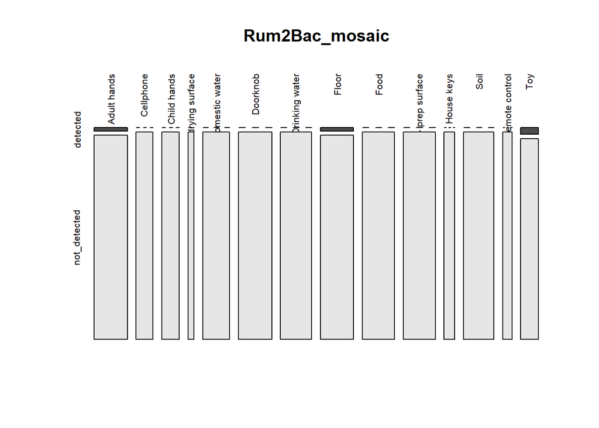

```r
#write.csv(fisher_HF183_multi_corrected$p.value, file="GFD_fisher_pvalues.csv")

fisher_GFD_posthoc <- fisher_GFD_multi_corrected$p.value %>%
  as.data.frame() %>%
  mutate(across(where(is.numeric), ~ case_when(
    is.na(.)    ~ "",
    . < 0.001   ~ "<0.001",
    TRUE        ~ formatC(., format = "f", digits = 3)
  )))
write.csv(fisher_GFD_posthoc, file = "fisher_GFD_posthoc.csv")


#Rum2Bac
Rum2Bac_counts<-prev%>%
  dplyr::group_by(Sample_Type)%>%
  dplyr::summarize(detected=sum(Rum2Bac))%>%
  dplyr::left_join(samples, by= "Sample_Type")%>%
  mutate(not_detected=Freq-detected)%>%
  select(-c(Freq))

Rum2Bac_mosaic<-Rum2Bac_counts%>%
  column_to_rownames("Sample_Type")%>%
  as.matrix()
mosaicplot(Rum2Bac_mosaic, color=TRUE, las=3)
```

```r
fisher_Rum2Bac<-Rum2Bac_counts%>%
  column_to_rownames("Sample_Type")%>%
  fisher_test(simulate.p.value = TRUE, B= 1e4)
fisher_Rum2Bac #ns; p>0.05
```

```
## # A tibble: 1 × 3
##       n     p p.signif
## * <dbl> <dbl> <chr>
## 1   585 0.706 ns
```

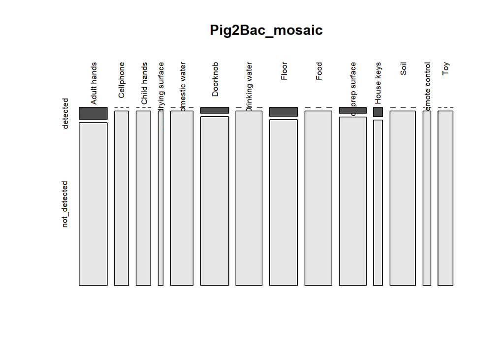

```r
#Pig2Bac
Pig2Bac_counts<-prev%>%
  dplyr::group_by(Sample_Type)%>%
  dplyr::summarize(detected=sum(Pig2Bac))%>%
  dplyr::left_join(samples, by= "Sample_Type")%>%
  mutate(not_detected=Freq-detected)%>%
  select(-c(Freq))

Pig2Bac_mosaic<-Pig2Bac_counts%>%
  column_to_rownames("Sample_Type")%>%
  as.matrix()
mosaicplot(Pig2Bac_mosaic, color=TRUE, las=3)
```

```r
fisher_Pig2Bac<-Pig2Bac_counts%>%
  column_to_rownames("Sample_Type")%>%
  fisher_test(simulate.p.value = TRUE, B= 1e4) #ns; p>0.05

#summarize p-values
prev_fisher<-list(GenBac=fisher_GenBac, HF183=fisher_HF183, DG37=fisher_DG37, GFD=fisher_GFD, Rum2Bac=fisher_Rum2Bac, Pig2Bac=fisher_Pig2Bac)
combined_prev_fisher<-map_df(prev_fisher, bind_rows, .id="source")
combined_prev_fisher
```

```
## # A tibble: 6 × 4
##   source      n      p p.signif
##   <chr>   <dbl>  <dbl> <chr>
## 1 GenBac    585 0.0001 ****
## 2 HF183     585 0.0001 ****
## 3 DG37      585 0.0001 ****
## 4 GFD       585 0.0001 ****
## 5 Rum2Bac   585 0.706  ns
## 6 Pig2Bac   585 0.173  ns
```

#Abundance plot

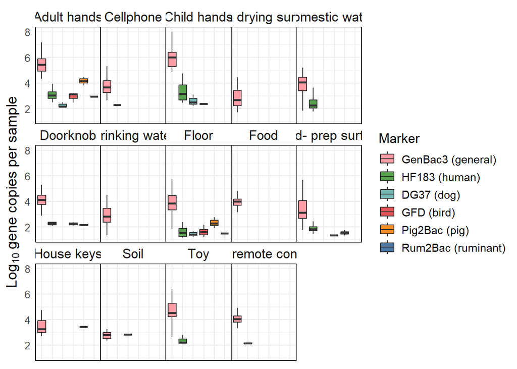

```r
data_melt<-read.csv("Updated_AnExII GenBac raw.csv")%>%
  mutate_at(vars(6:11), as.numeric)%>%
  mutate(GenBac_log=log10(GenBac))%>%
  mutate(HF183_log=log10(HF183))%>%
  mutate(DG37_log=log10(DG37))%>%
  mutate(GFD_log=log10(GFD))%>%
  mutate(Rum2Bac_log=log10(Rum2Bac))%>%
  mutate(Pig2Bac_log=log10(Pig2Bac))%>%
  mutate(Sample_Type = if_else(Sample_Type == "Mom's hands", "Adult hands", Sample_Type))%>%
  mutate(Sample_Type = if_else(Sample_Type == "Child's hands", "Child hands", Sample_Type))%>%
  select(c(Sample_Type, Code, Site, Household, GenBac_log, HF183_log, DG37_log, GFD_log, Rum2Bac_log, Pig2Bac_log))%>%
  melt(id.vars=c("Code", "Sample_Type", "Site", "Household"), variable.name=("measurement"), value.name="value")
data_melt$value<-as.numeric(data_melt$value)

data_melt$measurement <- factor(data_melt$measurement, levels = c("GenBac_log", "HF183_log", "DG37_log", "GFD_log", "Pig2Bac_log", "Rum2Bac_log"))

labels<-c("GenBac3 (general)", "HF183 (human)", "DG37 (dog)", "GFD (bird)", "Pig2Bac (pig)", "Rum2Bac (ruminant)")

cols <- c("GenBac_log"="#FF9DA7", "HF183_log"="#59A14F", "DG37_log"="#76B7B4", "GFD_log"="#E15759", "Pig2Bac_log"="#F28E2B", "Rum2Bac_log"="#4E79A7")

abundance_boxplot <- ggplot(data = data_melt,
                            aes(x = measurement, y = value, fill = measurement)) +
  geom_boxplot(outlier.shape = NA) +
  theme_minimal() +
  scale_fill_manual(values = cols, labels = labels) +
  scale_x_discrete(labels = labels) +
  guides(fill = guide_legend(title = "Marker")) +
  facet_wrap(~Sample_Type, nrow = 3) +
  labs(y = expression(Log[10]*" gene copies per sample")) +
  theme(
    axis.line = element_line(),
    axis.text.y = element_text(size = 10),
    axis.title.y = element_text(size = 14),
    legend.background = element_rect(color = NA),
    legend.text = element_text(size = 11),
    legend.title = element_text(size = 13),
    axis.text.x = element_blank(),
    axis.ticks.x = element_blank(),
    axis.title.x = element_blank(),
    strip.text.x = element_text(size = 13),
    panel.spacing.x = unit(0, "line"),
    panel.spacing.y = unit(0, "line"),
    panel.border = element_rect(color = "black", fill = NA)
  )

abundance_boxplot
```

#GenBac concentration testing

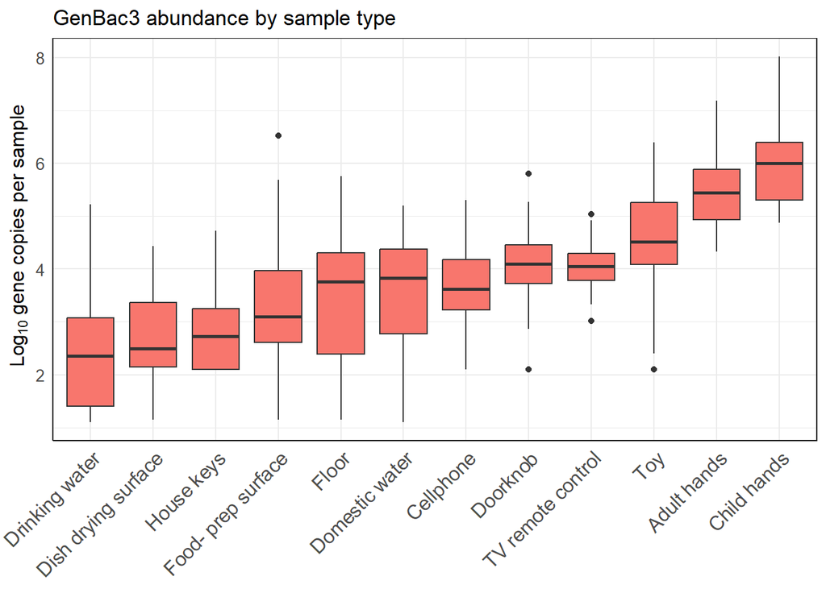

```r
#Plot abundances
GenBac_plot<-data%>%
  subset(!(Sample_Type %in% c("Food", "Soil"))) %>%
  ggplot(aes(x=reorder(Sample_Type, GenBac_log, na.rm=TRUE), GenBac_log, fill="#FF9DA7"))+
  geom_boxplot()+
  theme_minimal()+
  labs(y = expression(Log[10]*" gene copies per sample")) +
  ggtitle("GenBac3 abundance by sample type")+
  theme(axis.line=element_line(),
        axis.text.y=element_text(size=10),
        axis.title.y=element_text(size=12),
        legend.position="none",
        axis.ticks.x=element_blank(),
        axis.title.x=element_blank(),
        strip.text.x=element_text(size=13),
        panel.spacing.x=unit(0, "line"),
        panel.spacing.y=unit(0, "line"),
        panel.border=element_rect(color="black", fill=NA),
        axis.text.x = element_text(angle = 45, hjust=1, size=12))


GenBac_plot
```

```r
#normality
shapiro.test(data$GenBac_log) #data is non-normal
```

```
##
##  Shapiro-Wilk normality test
##
## data:  data$GenBac_log
## W = 0.98557, p-value = 1.564e-05
```

```r
#Kruskal Wallis testing by sample type
kruskal.test(data$GenBac_log ~ data$Sample_Type) #p<2.2e-16; run pairwise posthoc Dunn's tests
```

```
##
##  Kruskal-Wallis rank sum test
##
## data:  data$GenBac_log by data$Sample_Type
## Kruskal-Wallis chi-squared = 344.32, df = 13, p-value < 2.2e-16
```

```r
dunn_GenBac<-dunn_test(data=data, GenBac_log ~ Sample_Type, p.adjust.method="BH")
dunn_GenBac%>%
  select(-c(".y."))%>%
  mutate(across(where(is.numeric), ~ round(., 3)))%>%
  kbl()
```

group1

group2

n1

n2

statistic

p

p.adj

p.adj.signif

Adult hands

Cellphone

59

30

-5.422

0.000

0.000

Adult hands

Child hands

59

31

0.708

0.479

0.507

ns

Adult hands

Dish drying surface

59

10

-5.825

0.000

0.000

Adult hands

Domestic water

59

47

-7.045

0.000

0.000

Adult hands

Doorknob

59

59

-4.930

0.000

0.000

Adult hands

Drinking water

59

55

-12.054

0.000

0.000

Adult hands

Floor

59

59

-7.713

0.000

0.000

Adult hands

Food

59

57

-8.973

0.000

0.000

Adult hands

Food- prep surface

59

57

-8.747

0.000

0.000

Adult hands

House keys

59

19

-7.276

0.000

0.000

Adult hands

Soil

59

54

-13.128

0.000

0.000

Adult hands

Toy

59

31

-2.671

0.008

0.013

Adult hands

TV remote control

59

16

-3.232

0.001

0.002

Cellphone

Child hands

30

31

5.360

0.000

0.000

Cellphone

Dish drying surface

30

10

-2.126

0.033

0.052

ns

Cellphone

Domestic water

30

47

-0.692

0.489

0.512

ns

Cellphone

Doorknob

30

59

1.374

0.170

0.214

ns

Cellphone

Drinking water

30

55

-4.598

0.000

0.000

Cellphone

Floor

30

59

-0.912

0.362

0.392

ns

Cellphone

Food

30

57

-1.999

0.046

0.068

ns

Cellphone

Food- prep surface

30

57

-1.813

0.070

0.099

ns

Cellphone

House keys

30

19

-2.399

0.016

0.026

Cellphone

Soil

30

54

-5.519

0.000

0.000

Cellphone

Toy

30

31

2.434

0.015

0.024

Cellphone

TV remote control

30

16

0.984

0.325

0.365

ns

Child hands

Dish drying surface

31

10

-5.910

0.000

0.000

Child hands

Domestic water

31

47

-6.632

0.000

0.000

Child hands

Doorknob

31

59

-4.800

0.000

0.000

Child hands

Drinking water

31

55

-10.759

0.000

0.000

Child hands

Floor

31

59

-7.110

0.000

0.000

Child hands

Food

31

57

-8.172

0.000

0.000

Child hands

Food- prep surface

31

57

-7.983

0.000

0.000

Child hands

House keys

31

19

-7.126

0.000

0.000

Child hands

Soil

31

54

-11.669

0.000

0.000

Child hands

Toy

31

31

-2.951

0.003

0.006

Child hands

TV remote control

31

16

-3.470

0.001

0.001

Dish drying surface

Domestic water

10

47

1.765

0.077

0.107

ns

Dish drying surface

Doorknob

10

59

3.171

0.002

0.003

Dish drying surface

Drinking water

10

55

-0.777

0.437

0.468

ns

Dish drying surface

Floor

10

59

1.673

0.094

0.128

ns

Dish drying surface

Food

10

57

0.950

0.342

0.375

ns

Dish drying surface

Food- prep surface

10

57

1.072

0.284

0.327

ns

Dish drying surface

House keys

10

19

0.187

0.852

0.861

ns

Dish drying surface

Soil

10

54

-1.395

0.163

0.209

ns

Dish drying surface

Toy

10

31

3.849

0.000

0.000

***

Dish drying surface

TV remote control

10

16

2.682

0.007

0.013

Domestic water

Doorknob

47

59

2.402

0.016

0.026

Domestic water

Drinking water

47

55

-4.440

0.000

0.000

Domestic water

Floor

47

59

-0.219

0.827

0.845

ns

Domestic water

Food

47

57

-1.468

0.142

0.187

ns

Domestic water

Food- prep surface

47

57

-1.255

0.210

0.254

ns

Domestic water

House keys

47

19

-1.993

0.046

0.068

ns

Domestic water

Soil

47

54

-5.489

0.000

0.000

Domestic water

Toy

47

31

3.392

0.001

0.001

Domestic water

TV remote control

47

16

1.611

0.107

0.144

ns

Doorknob

Drinking water

59

55

-7.211

0.000

0.000

Doorknob

Floor

59

59

-2.783

0.005

0.010

Doorknob

Food

59

57

-4.086

0.000

0.000

***

Doorknob

Food- prep surface

59

57

-3.860

0.000

0.000

***

Doorknob

House keys

59

19

-3.834

0.000

0.000

***

Doorknob

Soil

59

54

-8.308

0.000

0.000

Doorknob

Toy

59

31

1.421

0.155

0.202

ns

Doorknob

TV remote control

59

16

-0.012

0.990

0.990

ns

Drinking water

Floor

55

59

4.477

0.000

0.000

Drinking water

Food

55

57

3.136

0.002

0.003

Drinking water

Food- prep surface

55

57

3.358

0.001

0.002

Drinking water

House keys

55

19

1.278

0.201

0.247

ns

Drinking water

Soil

55

54

-1.112

0.266

0.314

ns

Drinking water

Toy

55

31

7.422

0.000

0.000

Drinking water

TV remote control

55

16

4.746

0.000

0.000

Floor

Food

59

57

-1.327

0.185

0.230

ns

Floor

Food- prep surface

59

57

-1.101

0.271

0.316

ns

Floor

House keys

59

19

-1.892

0.059

0.085

ns

Floor

Soil

59

54

-5.587

0.000

0.000

Floor

Toy

59

31

3.731

0.000

0.000

***

Floor

TV remote control

59

16

1.806

0.071

0.099

ns

Food

Food- prep surface

57

57

0.224

0.823

0.845

ns

Food

House keys

57

19

-0.953

0.340

0.375

ns

Food

Soil

57

54

-4.243

0.000

0.000

Food

Toy

57

31

4.813

0.000

0.000

Food

TV remote control

57

16

2.670

0.008

0.013

Food- prep surface

House keys

57

19

-1.112

0.266

0.314

ns

Food- prep surface

Soil

57

54

-4.465

0.000

0.000

Food- prep surface

Toy

57

31

4.625

0.000

0.000

Food- prep surface

TV remote control

57

16

2.522

0.012

0.019

House keys

Soil

19

54

-2.074

0.038

0.058

ns

House keys

Toy

19

31

4.553

0.000

0.000

House keys

TV remote control

19

16

2.971

0.003

0.006

Soil

Toy

54

31

8.343

0.000

0.000

Soil

TV remote control

54

16

5.485

0.000

0.000

Toy

TV remote control

31

16

-1.035

0.301

0.342

ns

```r
write.csv(dunn_GenBac, file="Dunn_posthoc_GenBac.csv")
```

#Floor sample metadata

```r
prev_floor<-prev%>%
   subset(Sample_Type=="Floor")

Floor_types<-prev_floor %>%
  dplyr::group_by(Floor.type)%>%
  dplyr::rename(Floor=Floor.type)%>%
  dplyr::summarize(Count=n())

Floors_cleaned<-prev_floor %>%
  dplyr::group_by(floor.floor_cleaning)%>%
  dplyr::rename(Floor = floor.floor_cleaning)%>%
  dplyr::summarize(Count=n())

Floors<-Floor_types%>%
  rbind(Floors_cleaned)%>%
  kbl(col.names=NULL)%>%
  kable_styling(bootstrap_options="hover", full_width=F)%>%
  pack_rows("Floor Type", 1, 6)%>%
  pack_rows("Floors cleaned in past 24h", 7,8)%>%
  add_header_above(c("Floor sample metadata(n=59)"=2))
Floors
```

| Floor sample metadata(n=59) |  |
| --- | --- |
| **Floor Type** |  |
| Carpet | 1 |
| Cement | 22 |
| Ceramic tiles | 16 |
| Other | 1 |
| Vinyl/asphalt | 4 |
| Wooden boards | 15 |
| **Floors cleaned in past 24h** |  |
| No | 50 |
| Yes | 9 |

#Floor type and MST marker detection in floor samples

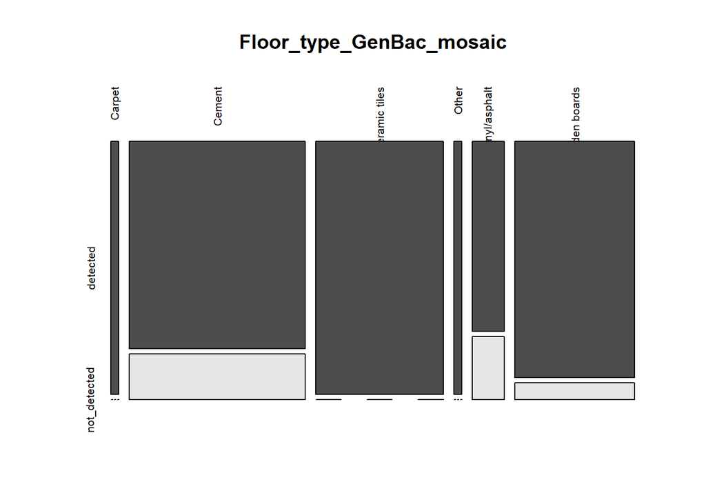

```r
#GenBac
Floor_type_GenBac_counts<-prev%>%
  dplyr::rename("Floor"="Floor.type")%>%
  subset(Sample_Type=="Floor")%>%
  dplyr::group_by(Floor)%>%
  dplyr::summarize(detected=sum(GenBac))%>%
  dplyr::left_join(Floor_types, by= "Floor")%>%
  dplyr::mutate(not_detected=Count-detected)%>%
  select(-c(Count))

Floor_type_GenBac_mosaic<-Floor_type_GenBac_counts%>%
  column_to_rownames("Floor")%>%
  as.matrix()
mosaicplot(Floor_type_GenBac_mosaic, color=TRUE, las=3)
```

```r
fisher_floor_type_GenBac<-Floor_type_GenBac_counts%>%
  column_to_rownames("Floor")%>%
  fisher_test(simulate.p.value = TRUE, B= 1e4)
fisher_floor_type_GenBac #ns; p>0.05
```

```
## # A tibble: 1 × 3
##       n     p p.signif
## * <dbl> <dbl> <chr>
## 1    59  0.34 ns
```

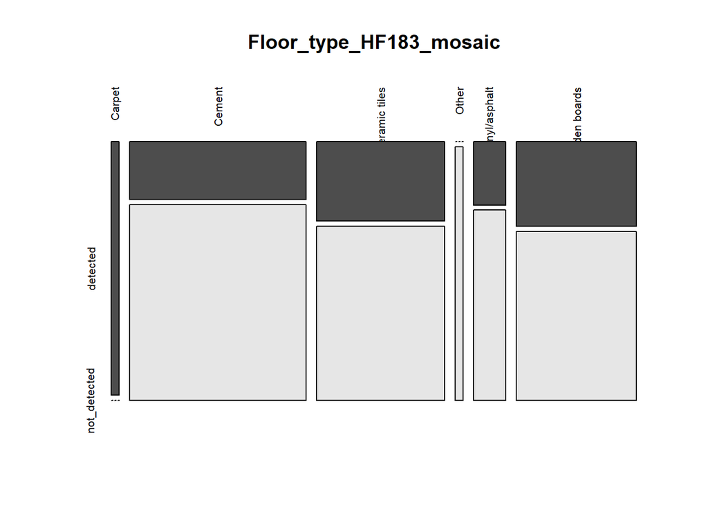

```r
#HF183
Floor_type_HF183_counts<-prev%>%
  dplyr::rename("Floor"="Floor.type")%>%
  subset(Sample_Type=="Floor")%>%
  dplyr::group_by(Floor)%>%
  dplyr::summarize(detected=sum(HF183))%>%
  left_join(Floor_types, by= "Floor")%>%
  mutate(not_detected=Count-detected)%>%
  select(-c(Count))

Floor_type_HF183_mosaic<-Floor_type_HF183_counts%>%
  column_to_rownames("Floor")%>%
  as.matrix()
mosaicplot(Floor_type_HF183_mosaic, color=TRUE, las=3)
```

```r
fisher_floor_type_HF183<-Floor_type_HF183_counts%>%
  column_to_rownames("Floor")%>%
  fisher_test(simulate.p.value = TRUE, B= 1e4)
fisher_floor_type_HF183 #ns; p>0.05
```

```
## # A tibble: 1 × 3
##       n     p p.signif
## * <dbl> <dbl> <chr>
## 1    59 0.693 ns
```

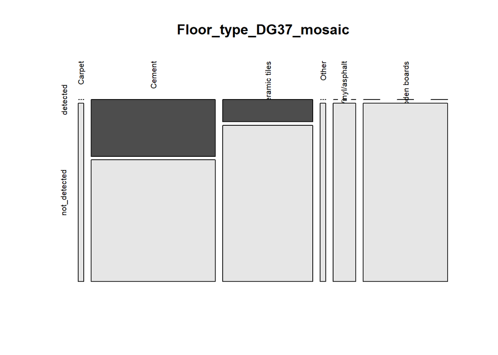

```r
#DG37
Floor_type_DG37_counts<-prev%>%
  dplyr::rename("Floor"="Floor.type")%>%
  subset(Sample_Type=="Floor")%>%
  dplyr::group_by(Floor)%>%
  dplyr::summarize(detected=sum(DG37))%>%
  left_join(Floor_types, by= "Floor")%>%
  mutate(not_detected=Count-detected)%>%
  select(-c(Count))

Floor_type_DG37_mosaic<-Floor_type_DG37_counts%>%
  column_to_rownames("Floor")%>%
  as.matrix()
mosaicplot(Floor_type_DG37_mosaic, color=TRUE, las=3)
```

```r
fisher_floor_type_DG37<-Floor_type_DG37_counts%>%
  column_to_rownames("Floor")%>%
  fisher_test(simulate.p.value = TRUE, B= 1e4)
fisher_floor_type_DG37 #ns; p>0.05
```

```
## # A tibble: 1 × 3
##       n     p p.signif
## * <dbl> <dbl> <chr>
## 1    59  0.14 ns
```

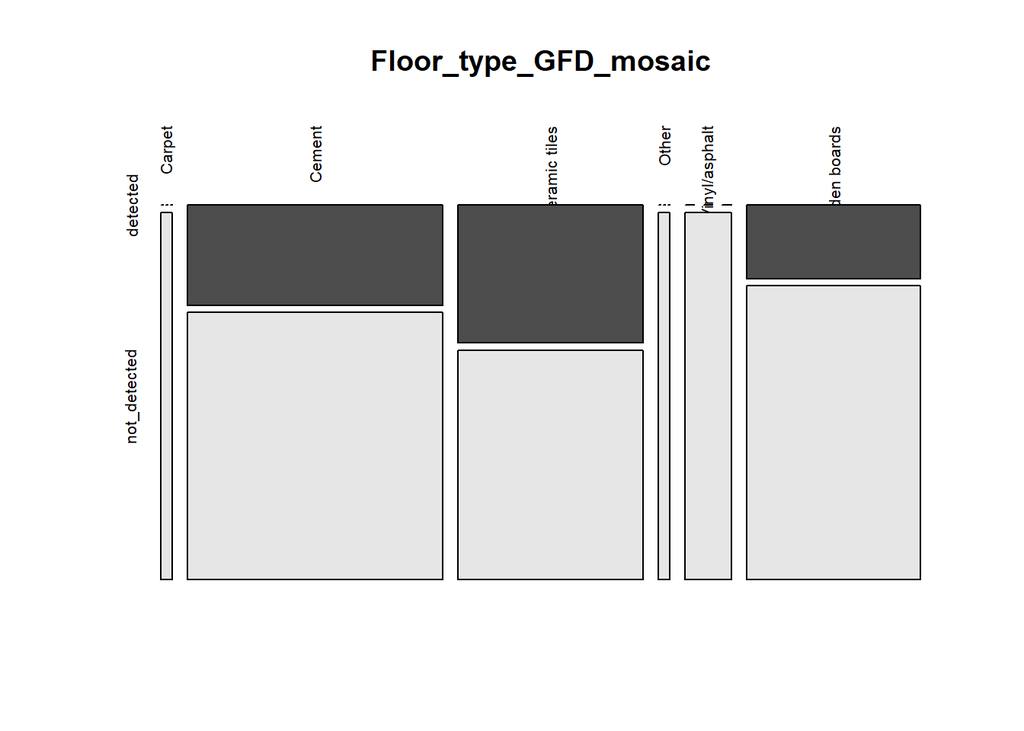

```r
#GFD
Floor_type_GFD_counts<-prev%>%
  dplyr::rename("Floor"="Floor.type")%>%
  subset(Sample_Type=="Floor")%>%
  dplyr::group_by(Floor)%>%
  dplyr::summarize(detected=sum(GFD))%>%
  left_join(Floor_types, by= "Floor")%>%
  mutate(not_detected=Count-detected)%>%
  select(-c(Count))

Floor_type_GFD_mosaic<-Floor_type_GFD_counts%>%
  column_to_rownames("Floor")%>%
  as.matrix()
mosaicplot(Floor_type_GFD_mosaic, color=TRUE, las=3)
```

```r
fisher_floor_type_GFD<-Floor_type_GFD_counts%>%
  column_to_rownames("Floor")%>%
  fisher_test(simulate.p.value = TRUE, B= 1e4)
fisher_floor_type_GFD #ns; p>0.0
```

```
## # A tibble: 1 × 3
##       n     p p.signif
## * <dbl> <dbl> <chr>
## 1    59 0.743 ns
```

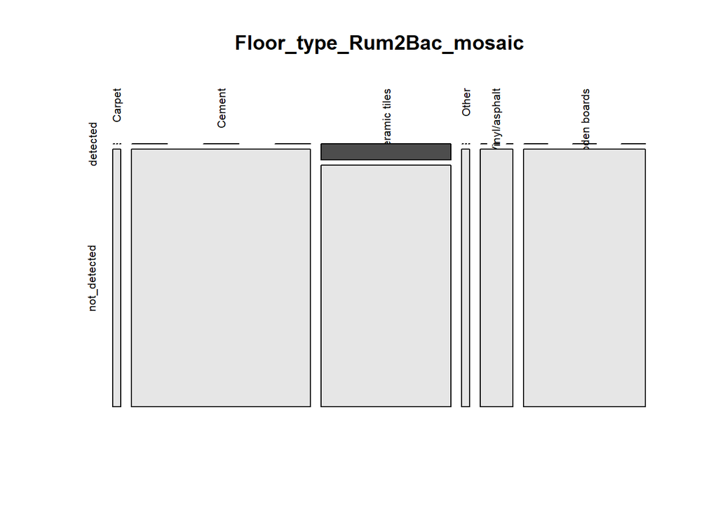

```r
#Rum2Bac
Floor_type_Rum2Bac_counts<-prev%>%
  dplyr::rename("Floor"="Floor.type")%>%
  subset(Sample_Type=="Floor")%>%
  dplyr::group_by(Floor)%>%
  dplyr::summarize(detected=sum(Rum2Bac))%>%
  left_join(Floor_types, by= "Floor")%>%
  mutate(not_detected=Count-detected)%>%
  select(-c(Count))

Floor_type_Rum2Bac_mosaic<-Floor_type_Rum2Bac_counts%>%
  column_to_rownames("Floor")%>%
  as.matrix()
mosaicplot(Floor_type_Rum2Bac_mosaic, color=TRUE, las=3)
```

```r
fisher_floor_type_Rum2Bac<-Floor_type_Rum2Bac_counts%>%
  column_to_rownames("Floor")%>%
  fisher_test(simulate.p.value = TRUE, B= 1e4)
fisher_floor_type_Rum2Bac #ns; p>0.0
```

```
## # A tibble: 1 × 3
##       n     p p.signif
## * <dbl> <dbl> <chr>
## 1    59 0.633 ns
```